# 07: Neural networks

```python
%matplotlib inline

import numpy as np
import pandas as pd
import seaborn as sns
import matplotlib.pyplot as plt

import mylib as my
```

## The Multilayer Perceptron

As the name implies, a multilayer perceptron (MLP) is a set of perceptrons arranged into layers. The goal here is to have a learner that:

- works for both regression and classification
- is a universal function approximator

To do this a few changes will need to be made to the perceptron:

- The threshold will need to be replaced with an activation function. In this notebook, we'll be using the sigmoid function: $$g(z) = \frac{1}{1 + e^{-z}}$$
- A differentiable loss function will need to be used. We'll use the $L_2$ loss function in this notebook.

With the above in mind, we can obtain an MLP learner by having one or more layers between the input and output. The figure below depicts an MLP with one hidden layer. This is the quintessential neural network (NN); it is fully connected and feed-forward.

The figure below shows an example MLP network.

[figure not shown]

Let's implement this MLP network from scratch in a step by step manner. After that, we'll put everything together in a class.

### Determining the shape of the MLP network

In MLP:

- the number of features in the dataset determines how many nodes in the input layer
- the hidden layer can have as many nodes as needed. So we'll need a variable(say `nHidden`) to hold that number
- the output layer can have more than one node. This works well for multi-class classification.

These numbers determine the shape of the network. Here are some example values:

```python
nFeatures = 2 # Used to determine how many nodes in the input layer
nHidden = 2   # Used to determine how many nodes in the hidden layer
nOutput = 1   # Used to determine how many nodes in the output layer
```

Training an MLP model involves two main operations:

### A) Moving forward

Moving forward means taking an input and passing it across the network until the output is reached and calculated.

```python
def forward(inputs):
    """Assumes that inputs cotains the bias column"""

    # Calculaing the activations of the hidden nodes
    a = np.dot(inputs, w);
    a = 1.0/(1.0 + np.exp(-a))

    # Adding bias to the hidden nodes
    a = np.concatenate([np.ones((len(inputs), 1)), a], axis=1)

    # Calculating the output
    y = np.dot(a, v);

    return a, (1.0 / (1.0 + np.exp(-y)))
```

Moving backward means updating the weights of the network (where the actual learning happens) such that the loss function at the output layer is minimized. Because the we only know the error at the output layer, we need to propagate there error backward in order to update these weights in a way that minimize that error. We call this **backpropagation**.

First we calculate a few error quantities at both the output and hidden layers using the following formulas (in matrix notation):

$$\delta_o = (\mathbf{y} - \mathbf{t}) \mathbf{y} (1 - \mathbf{y})$$$$\delta_h = \mathbf{a} (1 - \mathbf{a}) \delta_o \mathbf{v}^T$$

where $\mathbf{t}$ is the actual target output, $\mathbf{y}$ is the predicted output, $\mathbf{a}$ are the activations of the hidden layers as the figure above shows.

We use these perceived errors to update the weights:

$$ \mathbf{w} = \mathbf{w} - \eta \mathbf{X} \delta_h^*$$$$ \mathbf{v} = \mathbf{v} - \eta \mathbf{a} \delta_a$$

where $\delta_h^*$ is the same as $\delta_h$ except that the first bias column is removed. Again this is the backpropagation and here is a function to implement it.

```python
def backward(inputs, target, a, y, eta):
    global w, v
    a, y = forward(inputs)

    error = 0.5* np.sum((y - target)**2)
    errors.append(error)

    # Calculate the "perceived errors"
    delta_o = (y - target) * y *(1.0 - y)
    delta_h = a *(1.0 - a) * (np.dot(delta_o, np.transpose(v)))

    # Update weights
    w -= eta * (np.dot(np.transpose(inputs),delta_h[:, 1:]))
    v -= eta * (np.dot(np.transpose(a), delta_o))
```

### Fitting the data

We can now use the above forward and backward functions to fit (train) the MLP network to the data. This is where the "learning" happens. We start by initializing the weights. As the above figure shows, we have two sets of weights:

- The weights $w_{ij}$ between the input layer and the hidden layer.
- The weights $v_{jk}$ between the hidden layer and the output layer.

These weights will need to be initialized properly. A good rule of thump is to initialize them to a random number between $[-1/\sqrt{n}, +1/\sqrt{n}]$ where $n$ is the number of nodes in layer preceding these weights.

```python
w = None
v = None
def fit(inputs, target, eta=.2, epochs=1000):
    # Initialze weights
    global w, v
    w = (np.random.rand(nFeatures + 1, nHidden)-0.5) * 2 / np.sqrt(nFeatures)
    v = (np.random.rand(nHidden + 1, nOutput)-0.5) *2/np.sqrt(nHidden)

    # Adding bias to the input nodes
    inputs = np.concatenate((np.ones((len(inputs),1)), inputs),axis=1)
    for n in range(epochs):
        backward(inputs, target, *forward(inputs), eta)
```

### Making predictions

Having fit the data, we now can use the trained network to make predictions. Here is a function that performs classification. This function uses `.05` as a threshold function: if $y > .5$, return 1 else return 0.

```python
def predict(unseen):
    if unseen.ndim == 1:
        unseen = unseen.reshape(1, len(unseen))

    # Adding bias to unseen
    unseen = np.concatenate((np.ones((len(unseen),1)), unseen),axis=1)
    h, y = forward(unseen)

    return np.where(y > 0.5, 1, 0)
```

### Testing the implementation

What better examples to test this implementation with than the AND, OR, and XOR data:

```python
logical_data = {
    'AND': pd.DataFrame(np.array([[0,0,0],[0,1,0],[1,0,0],[1,1,1]]), columns=['x1', 'x2', 'y']), # AND
    'OR ': pd.DataFrame(np.array([[0,0,0],[0,1,1],[1,0,1],[1,1,1]]), columns=['x1', 'x2', 'y']), # OR
    'XOR': pd.DataFrame(np.array([[0,0,0],[0,1,1],[1,0,1],[1,1,0]]), columns=['x1', 'x2', 'y'])  # XOR
}
```

Here how this data look:

```python
for title, df in logical_data.items():
    print(f".....{title}.....")
    print(df)
```

```
.....AND.....
   x1  x2  y
0   0   0  0
1   0   1  0
2   1   0  0
3   1   1  1
.....OR .....
   x1  x2  y
0   0   0  0
1   0   1  1
2   1   0  1
3   1   1  1
.....XOR.....
   x1  x2  y
0   0   0  0
1   0   1  1
2   1   0  1
3   1   1  0
```

We train three different MLP's (one for each operation) on this data and plot their learning curves.

```
[[3 0]
 [0 1]]
AND accuracy:  1.0
[[1 0]
 [0 3]]
OR  accuracy:  1.0
[[2 0]
 [1 1]]
XOR accuracy:  0.75
```

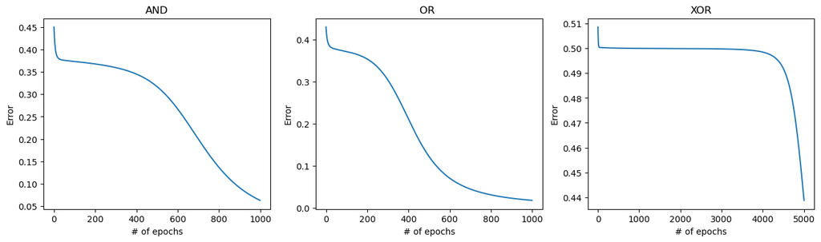

```python
fig = plt.figure(figsize=(16,4))
epochs = [1000, 1000, 5000]
for i, (title, df) in enumerate(logical_data.items()):
    ds = my.DataSet(df, y=True)

    errors = []
    fit(ds.inputs, ds.target, epochs=epochs[i])
    cm = my.confusion_matrix(ds.target, predict(ds.inputs))
    accuracy = np.trace(cm) / np.sum(cm)
    print(cm)
    print(title, 'accuracy: ', accuracy)

    ax = fig.add_subplot(1,3, i + 1)
    ax.plot(errors)
    ax.set_xlabel('# of epochs')
    ax.set_ylabel('Error')
    plt.title(title)
```

## Putting everything together: The MLP class

Let's put all this together into a class. This class will be able to carry out both binary and multi-class classifications. For the latter (multi-class classification), two changes are needed:

- The output column will need to be one-hot encoded.
- The predict function will be changed to return the class (label) with the large output probability

```python
class MultilayerPerceptron:
    def __init__(self, dataset, nHidden=None, eta=.2, epochs=1000):
        """
        nHidden: determines how many nodes in the hidden layer
        eta: the learning rate
        epochs: how many times the whole dataset is gone over
        """
        self.labels = np.unique(dataset.examples.iloc[:, -1])
        self.inputs = dataset.examples.values[:, :-1]
        self.target = dataset.examples.values[:, -1:]

        """
        nOutput: determines how many nodes in the output layer. For binary classification
                 nOutput = 1. For multi-class classification, one-hot-encoding is used
                 and nOutput = the number unique classes (labels) in the output column.
        """
        self.nOutput = 1

        """ One-hot-encoding to support multi-class classification """
        if len(self.labels) > 2:
            self.nOutput = len(self.labels)

            self.target = pd.DataFrame({
                f"y{i + 1}": dataset.examples.iloc[:, -1].apply(
                    lambda x: 1 if x == self.labels[i] else 0
                ) for i in range(self.nOutput)
            }).values

        self.nFeatures = self.inputs.shape[1]
        self.nHidden = self.nFeatures if nHidden == None else nHidden
        self.eta = eta
        self.epochs = epochs
        self.w = []

    def activation_f(self, h):
        """
        The activation (sigmoid) function
        """
        return 1.0/(1.0 + np.exp(-h))

    def forward(self, X):
        if len(self.w) == 0:
            raise "Need to fit the data first"

        X = np.concatenate([np.ones((len(X),1)), X],axis=1)

        # Hidden layer 1
        self.a = []
        a0 = self.activation_f(np.dot(X, self.w[0]));

        # Adding bias to the hidden nodes
        a0 = np.concatenate([np.ones((len(a0), 1)), a0], axis=1)
        self.a.append(a0)

        return X, self.activation_f(np.dot(self.a[0], self.w[1]))

    def backward(self, X, y):
        self.errors.append(0.5* np.sum((y - self.target)**2))

        # Calculate the "perceived errors"
        delta_o = (y - self.target) * y *(1.0 - y)
        delta_h = self.a[0] *(1.0 - self.a[0]) * (np.dot(delta_o, self.w[1].T))

        # Update weights
        self.w[0] -= self.eta * (np.dot(X.T, delta_h[:,1:]))
        self.w[1] -= self.eta * (np.dot(self.a[0].T, delta_o))

    def __initialize_weights(self):
        self.w.append((np.random.rand(self.nFeatures + 1, self.nHidden) - 0.5) * 2 / np.sqrt(self.nFeatures))
        self.w.append((np.random.rand(self.nHidden + 1, self.nOutput)-0.5) * 2 / np.sqrt(self.nHidden))

    def fit(self):
        self.errors = []
        self.__initialize_weights()

        for n in range(self.epochs):
            self.backward(*self.forward(self.inputs))

    def predict(self, unseen):
        if unseen.ndim == 1:
            unseen = unseen.reshape(1, len(unseen))

        X, y = self.forward(unseen)
        if self.target.shape[1] == 1:
            return np.where(y > 0.5, 1, 0)
        else: # For multi-class classification
            return np.argmax(y,1)
```

### Binary classification with MLP

We test this class using the `column_2C_weka` dataset from [kaggle](https://www.kaggle.com/datasets/displaynamenow/column-2c-wekacsv) which looks like this:

```python
df = pd.read_csv('datasets/column_2C_weka.csv')
df
```

|  | pelvic_incidence | pelvic_tilt numeric | lumbar_lordosis_angle | sacral_slope | pelvic_radius | degree_spondylolisthesis | class |
| --- | --- | --- | --- | --- | --- | --- | --- |
| 0 | 63.027817 | 22.552586 | 39.609117 | 40.475232 | 98.672917 | -0.254400 | Abnormal |
| 1 | 39.056951 | 10.060991 | 25.015378 | 28.995960 | 114.405425 | 4.564259 | Abnormal |
| 2 | 68.832021 | 22.218482 | 50.092194 | 46.613539 | 105.985135 | -3.530317 | Abnormal |
| 3 | 69.297008 | 24.652878 | 44.311238 | 44.644130 | 101.868495 | 11.211523 | Abnormal |
| 4 | 49.712859 | 9.652075 | 28.317406 | 40.060784 | 108.168725 | 7.918501 | Abnormal |
| ... | ... | ... | ... | ... | ... | ... | ... |
| 305 | 47.903565 | 13.616688 | 36.000000 | 34.286877 | 117.449062 | -4.245395 | Normal |
| 306 | 53.936748 | 20.721496 | 29.220534 | 33.215251 | 114.365845 | -0.421010 | Normal |
| 307 | 61.446597 | 22.694968 | 46.170347 | 38.751628 | 125.670725 | -2.707880 | Normal |
| 308 | 45.252792 | 8.693157 | 41.583126 | 36.559635 | 118.545842 | 0.214750 | Normal |
| 309 | 33.841641 | 5.073991 | 36.641233 | 28.767649 | 123.945244 | -0.199249 | Normal |

310 rows × 7 columns

We'll need to encode the classes using numeric values: 0 for `Abnormal` and 1 for `Normal`. Here are the learning curves showing how the MLP performs on this dataset.

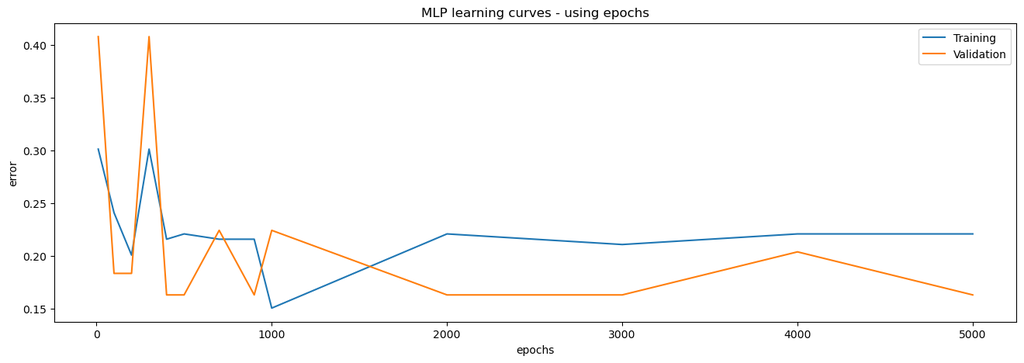

```python
# Recode the classes to 0 for Abnormal and 1 for Normal
df.iloc[:, -1] = df.iloc[:, -1].apply(lambda x: 0 if x == 'Abnormal' else 1)

ds = my.DataSet(df, y=True)

rest, test = ds.train_test_split(test_portion=.2, shuffle=True)
train, vald = rest.train_test_split(test_portion=.2)

epochs = [10, 100, 200, 300, 400, 500, 700, 900, 1000, 2000, 3000, 4000, 5000]
train_err = []
vald_err = []
for n in epochs:
    mlp = MultilayerPerceptron(train, nHidden=15, epochs=n, eta=.01)
    mlp.fit()

    cm = my.confusion_matrix(train.target, mlp.predict(train.inputs))
    train_err.append(1 - np.trace(cm) / np.sum(cm))

    cm = my.confusion_matrix(vald.target, mlp.predict(vald.inputs))
    vald_err.append(1 - np.trace(cm) / np.sum(cm))

fig = plt.figure(figsize=(16,5))
ax = fig.add_subplot(1, 1, 1)
ax.plot(epochs, train_err, label="Training")
ax.plot(epochs, vald_err, label="Validation")
ax.set_xlabel("epochs")
ax.set_ylabel("error")
ax.legend()
ax.set_title("MLP learning curves - using epochs")
```

If you look at this dataset again, you'll see that some of the input columns have large values, and some have small ones. If you get a runtime warning regrading overflow in the `exp` operation, it is because of of these large values. In addition, the curves have ups and downs at multiple points.

Here is the best value for the `epochs` hyperparameter .

```python
epochs[np.argmin(vald_err)]
```

```
400
```

Testing with this value gives us the following:

```python
mlp = MultilayerPerceptron(rest, nHidden=15, epochs=epochs[np.argmin(vald_err)], eta=.01)
mlp.fit()

cm = my.confusion_matrix(test.target, mlp.predict(test.inputs))
accuracy = np.trace(cm) / np.sum(cm)
print(cm)
print('Testing accuracy: ', accuracy)
```

```
[[30 12]
 [ 1 19]]
Testing accuracy:  0.7903225806451613
```

To address the above problems, we make sure that large-valued columns don't render small-valued ones insignificant. We can do that by scaling the input values in one of two ways: standardization or normalization. Standardization uses the formula:

$$ x_{new} = \frac{x - x_{mean}}{x_{std. dev.}}$$

to scale the input values. Normalization (min-max scaling) uses the formula:

$$ x_{new} = \frac{x - x_{min}}{x_{max} - x_{min}}$$

to scale the input values.

Here how the same MLP as above performs on standardized data:

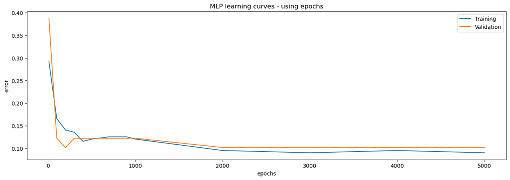

```python
standarized_df=(df.iloc[:, :-1]-df.iloc[:, :-1].mean())/df.iloc[:, :-1].std()

ds = my.DataSet(pd.concat([standarized_df, df.iloc[:, -1]], axis=1), y=True)

rest, test = ds.train_test_split(test_portion=.2, shuffle=True)
train, vald = rest.train_test_split(test_portion=.2)

epochs = [10, 100, 200, 300, 400, 500, 700, 900, 1000, 2000, 3000, 4000, 5000]
train_err = []
vald_err = []
for n in epochs:
    mlp = MultilayerPerceptron(train, nHidden=15, epochs=n, eta=.01)
    mlp.fit()

    cm = my.confusion_matrix(train.target, mlp.predict(train.inputs))
    train_err.append(1 - np.trace(cm) / np.sum(cm))

    cm = my.confusion_matrix(vald.target, mlp.predict(vald.inputs))
    vald_err.append(1 - np.trace(cm) / np.sum(cm))

fig = plt.figure(figsize=(16,5))
ax = fig.add_subplot(1, 1, 1)
ax.plot(epochs, train_err, label="Training")
ax.plot(epochs, vald_err, label="Validation")
ax.set_xlabel("epochs")
ax.set_ylabel("error")
ax.legend()
ax.set_title("MLP learning curves - using epochs")
```

The column standardization makes the curves smoother. They also help avoid the overflow problems we saw earlier. Here is the best epoch value.

```python
epochs[np.argmin(vald_err)]
```

```
200
```

Let's test with it:

```python
mlp = MultilayerPerceptron(rest, nHidden=15, epochs=epochs[np.argmin(vald_err)], eta=.01)
mlp.fit()

cm = my.confusion_matrix(test.target, mlp.predict(test.inputs))
accuracy = np.trace(cm) / np.sum(cm)
print(cm)
print('Testing accuracy: ', accuracy)
```

```
[[36  3]
 [ 6 17]]
Testing accuracy:  0.8548387096774194
```

which gives a better performance.

## Multiclass classification with MLP

We can use the MLP to perform multi-class classification by one-hot encoding the classes such that we have one target column for each class. See [one-hot encoding](https://www.kaggle.com/dansbecker/using-categorical-data-with-one-hot-encoding) for more information. In this example, we use the Iris dataset collected by sir R. A. Fisher. *Notice that the one-hot encoding is done done automatically for us by the MLP class.*

```python
data = sns.load_dataset("iris")
data.iloc[:, -1] = data.iloc[:, -1].apply(lambda x: 0 if x == 'setosa' else (1 if x == 'versicolor' else 2))

ds = my.DataSet(data, y=True)

train, test = ds.train_test_split(test_portion=.25, shuffle=True)


mlp = MultilayerPerceptron(train, nHidden=15, epochs=1000, eta=.01)
mlp.fit()

cm = my.confusion_matrix(train.target, mlp.predict(train.inputs))
accuracy = np.trace(cm) / np.sum(cm)
print(cm)
print('Training accuracy: ', accuracy)

cm = my.confusion_matrix(test.target, mlp.predict(test.inputs))
accuracy = np.trace(cm) / np.sum(cm)
print(cm)
print('Testing accuracy: ', accuracy)
```

```
[[39  0  0]
 [ 0 36  0]
 [ 0  0 38]]
Training accuracy:  1.0
[[11  0  0]
 [ 0 11  3]
 [ 0  0 12]]
Testing accuracy:  0.918918918918919
```

Here is another example using a different dataset.

```
[[190   0   0]
 [  0 187   0]
 [  0   0 186]]
Training accuracy:  1.0
[[60  0  0]
 [ 0 63  0]
 [ 0  0 64]]
Testing accuracy:  1.0
```

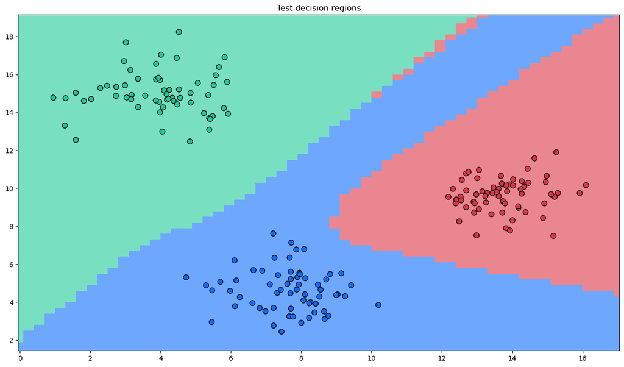

```python
df = pd.read_csv('datasets/sample3cls.csv')
ds = my.DataSet(df, y=True)

train, test = ds.train_test_split(test_portion=.25, shuffle=True)

mlp = MultilayerPerceptron(train, nHidden=15, epochs=3000, eta=.01)
mlp.fit()

cm = my.confusion_matrix(train.target, mlp.predict(train.inputs))
accuracy = np.trace(cm) / np.sum(cm)
print(cm)
print('Training accuracy: ', accuracy)

cm = my.confusion_matrix(test.target, mlp.predict(test.inputs))
accuracy = np.trace(cm) / np.sum(cm)
print(cm)
print('Testing accuracy: ', accuracy)

my.plot_decision_regions(test.inputs, test.target, mlp, resolution=0.3, title="Test decision regions")
```

## A final example

Let's use the MLP to predict the hand-written digits of the MNIST (Modified National Institute of Standards and Technology) dataset. We start by importing the preprocessed digits dataset form scikit-learn's datasets. That requires installing scikit-learn first. Use the following commands to do that:

```
conda activate ml
conda install scikit-learn
```

Let's import scikit-learn's datasets:

```python
from sklearn import datasets
```

Let's load the MNIST dataset. Keep in mind that this dataset has been processed, and each image has been reduced to 8 by 8 pixels. Every pixel is represented in the input by a color value between 0 and 16.

```python
digits = datasets.load_digits()
```

The `digits` dataset has two instance variables: `images` for the input and `target` for the output labels. Let's take a look at some of these digits:

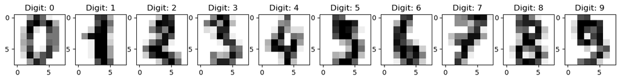

```python
fig = plt.figure(1, figsize=(16, 7))
for i in range(0, 10):
    ax = fig.add_subplot(1, 10, i + 1)
    ax.imshow(digits.images[i], cmap=plt.cm.gray_r, interpolation='nearest')
    ax.set_title(f"Digit: {digits.target[i]}")
```

We start by reshaping each image to a row with 64 features (one per pixel). We also need to normalize the color values.

```python
X = digits.images.reshape(1797, 64)
X = X / 16 # Input normalization
y = digits.target.reshape(len(digits.target), 1)
ds = my.DataSet(pd.DataFrame(np.concatenate((X, y), axis=1)), y=True)
ds
```

```
        0    1       2       3       4       5       6    7    8       9  ...  \
0     0.0  0.0  0.3125  0.8125  0.5625  0.0625  0.0000  0.0  0.0  0.0000  ...
1     0.0  0.0  0.0000  0.7500  0.8125  0.3125  0.0000  0.0  0.0  0.0000  ...
2     0.0  0.0  0.0000  0.2500  0.9375  0.7500  0.0000  0.0  0.0  0.0000  ...
3     0.0  0.0  0.4375  0.9375  0.8125  0.0625  0.0000  0.0  0.0  0.5000  ...
4     0.0  0.0  0.0000  0.0625  0.6875  0.0000  0.0000  0.0  0.0  0.0000  ...
...   ...  ...     ...     ...     ...     ...     ...  ...  ...     ...  ...
1792  0.0  0.0  0.2500  0.6250  0.8125  0.3750  0.0000  0.0  0.0  0.0625  ...
1793  0.0  0.0  0.3750  1.0000  0.8125  0.6875  0.0625  0.0  0.0  0.0000  ...
1794  0.0  0.0  0.0625  0.6875  0.9375  0.0625  0.0000  0.0  0.0  0.0000  ...
1795  0.0  0.0  0.1250  0.6250  0.4375  0.0000  0.0000  0.0  0.0  0.0000  ...
1796  0.0  0.0  0.6250  0.8750  0.5000  0.0625  0.0000  0.0  0.0  0.1250  ...

       55   56      57      58      59      60      61      62   63    y
0     0.0  0.0  0.0000  0.3750  0.8125  0.6250  0.0000  0.0000  0.0  0.0
1     0.0  0.0  0.0000  0.0000  0.6875  1.0000  0.6250  0.0000  0.0  1.0
2     0.0  0.0  0.0000  0.0000  0.1875  0.6875  1.0000  0.5625  0.0  2.0
3     0.0  0.0  0.0000  0.4375  0.8125  0.8125  0.5625  0.0000  0.0  3.0
4     0.0  0.0  0.0000  0.0000  0.1250  1.0000  0.2500  0.0000  0.0  4.0
...   ...  ...     ...     ...     ...     ...     ...     ...  ...  ...
1792  0.0  0.0  0.0000  0.1250  0.8750  0.9375  0.5625  0.0000  0.0  9.0
1793  0.0  0.0  0.0000  0.3750  1.0000  0.8750  0.3750  0.0000  0.0  0.0
1794  0.0  0.0  0.0000  0.1250  0.5625  0.8125  0.3750  0.0000  0.0  8.0
1795  0.0  0.0  0.0000  0.3125  0.7500  1.0000  0.7500  0.0000  0.0  9.0
1796  0.0  0.0  0.0625  0.5000  0.7500  0.8750  0.7500  0.0625  0.0  8.0

[1797 rows x 65 columns]
```

Let's train an MLP to classify this data:

```python
train, test = ds.train_test_split(test_portion=.2, shuffle=True)

mlp = MultilayerPerceptron(train, nHidden=15, epochs=1000, eta=.01)
mlp.fit()

cm = my.confusion_matrix(train.target, mlp.predict(train.inputs))
accuracy = np.trace(cm) / np.sum(cm)
print(cm)
print('Training accuracy: ', accuracy)

cm = my.confusion_matrix(test.target, mlp.predict(test.inputs))
accuracy = np.trace(cm) / np.sum(cm)
print(cm)
print('Testing accuracy: ', accuracy)
```

```
[[137   0   0   0   0   0   0   0   0   0]
 [  0 148   0   0   0   0   0   0   0   0]
 [  0   0 139   0   0   0   0   0   0   0]
 [  0   0   0 149   0   0   1   0   0   0]
 [  0   0   0   0 147   0   0   0   1   3]
 [  0   0   0   0   0 138   0   0   0   2]
 [  0   1   0   0   0   0 147   0   0   0]
 [  0   0   0   0   0   0   0 146   0   0]
 [  0   0   0   0   0   0   0   1 125   1]
 [  0   0   0   0   0   0   0   0   1 151]]
Training accuracy:  0.9923504867872045
[[40  0  0  0  1  0  0  0  0  0]
 [ 0 33  0  0  0  1  0  0  0  0]
 [ 0  2 36  0  0  0  0  0  0  0]
 [ 0  0  2 31  0  0  0  0  0  0]
 [ 1  0  0  0 28  0  1  0  0  0]
 [ 0  0  1  0  1 40  0  0  0  0]
 [ 0  0  0  0  0  0 33  0  0  0]
 [ 0  0  0  0  1  0  0 32  0  0]
 [ 0  2  0  0  0  0  0  0 45  0]
 [ 0  0  0  0  0  1  0  0  0 27]]
Testing accuracy:  0.9610027855153204
```

Here are what the learning curves look like:

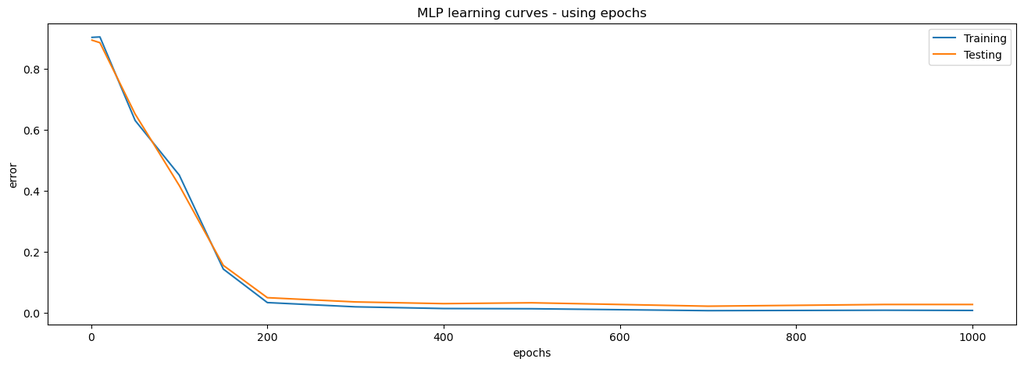

```python
epochs = [1, 10, 50, 100, 150, 200, 300, 400, 500, 700, 900, 1000]
train_err = []
test_err = []
for n in epochs:
    mlp = MultilayerPerceptron(train, nHidden=15, epochs=n, eta=.01)
    mlp.fit()

    cm = my.confusion_matrix(train.target, mlp.predict(train.inputs))
    train_err.append(1 - np.trace(cm) / np.sum(cm))

    cm = my.confusion_matrix(test.target, mlp.predict(test.inputs))
    test_err.append(1 - np.trace(cm) / np.sum(cm))

fig = plt.figure(figsize=(16,5))
ax = fig.add_subplot(1, 1, 1)
ax.plot(epochs, train_err, label="Training")
ax.plot(epochs, test_err, label="Testing")
ax.set_xlabel("epochs")
ax.set_ylabel("error")
ax.legend()
ax.set_title("MLP learning curves - using epochs")
```

## CHALLENGE

```
Modified version of the iris dataset with the responses coded as 0,1,2
             x1         x2    y
0     3.905427  15.778843  0.0
1     3.537138  13.491655  0.0
2     7.113054  13.679522  0.0
3     4.476505  15.279494  0.0
4     3.195807  15.074201  0.0
..         ...        ...  ...
745  13.821740   7.900900  2.0
746  14.631776  11.584164  2.0
747  12.708312   9.582081  2.0
748  15.076460   9.996624  2.0
749  15.283298   9.853758  2.0

[750 rows x 3 columns]
[[194   0   0]
 [  0 182   0]
 [  0   0 187]]
Training accuracy:  1.0
[[56  0  0]
 [ 0 68  0]
 [ 0  0 63]]
Testing accuracy:  1.0
```

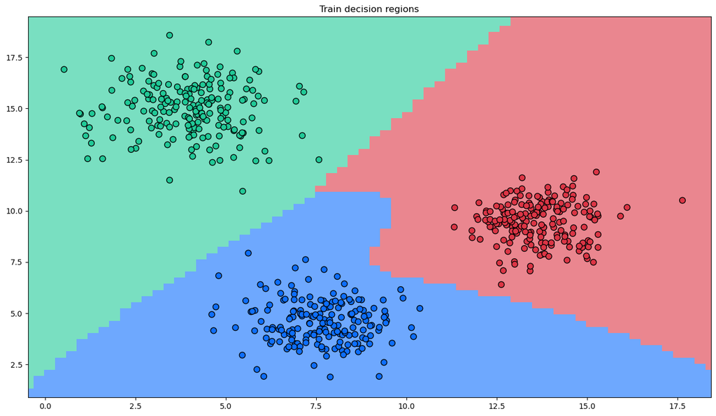

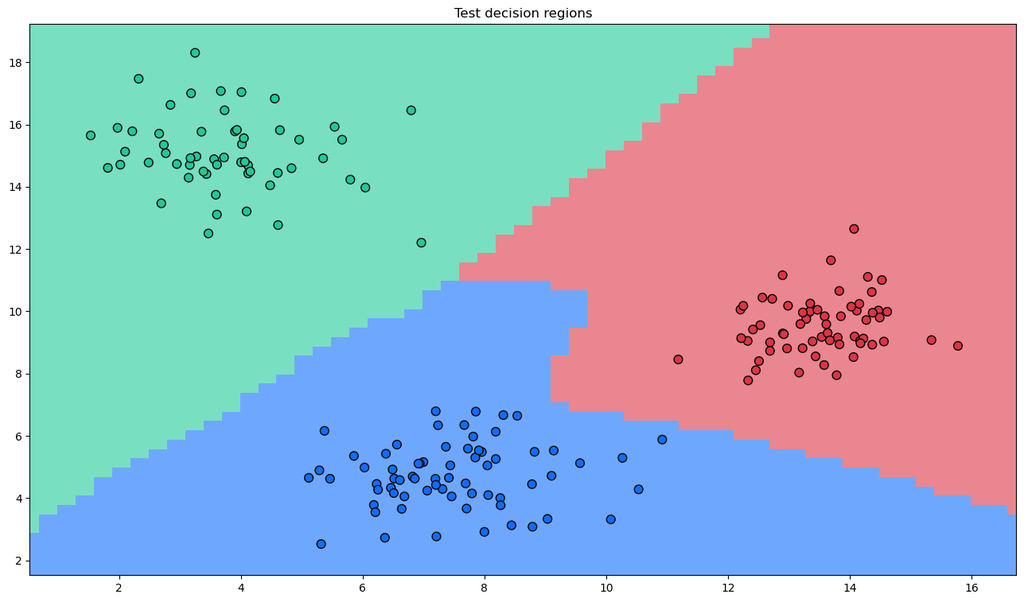

```python
df = pd.read_csv('datasets/sample3cls.csv')
ds = my.DataSet(df, y=True)

print(f"Modified version of the iris dataset with the responses coded as 0,1,2\n {df}")
train, test = ds.train_test_split(test_portion=.25, shuffle=True)

mlp = MultilayerPerceptron(train, nHidden=10, epochs=2000, eta=.01)
mlp.fit()

cm = my.confusion_matrix(train.target, mlp.predict(train.inputs))
accuracy = np.trace(cm) / np.sum(cm)
print(cm)
print('Training accuracy: ', accuracy)

cm = my.confusion_matrix(test.target, mlp.predict(test.inputs))
accuracy = np.trace(cm) / np.sum(cm)
print(cm)
print('Testing accuracy: ', accuracy)

my.plot_decision_regions(train.inputs, train.target, mlp, resolution=0.3, title="Train decision regions")
my.plot_decision_regions(test.inputs, test.target, mlp, resolution=0.3, title="Test decision regions")
```